# Image Captioning Using Recursive Neural Networks and Convolutional Neural Networks

Statistical and Machine Learning (40.319)

Tan Hong Zhang, Goh Khiam Hee

12/04/2023, Term 6 2023

# Project Description/ Hook

In recent years, more attention has been directed towards Artificial Intelligence (AI) image captioning as it enables machines to understand and describe the contents of images in natural language, just like humans do. Such technology can ease multiple processes and help with organisation and retrieval, such as image annotation for medical services, or tagging of photos for photography. Furthermore, this topic of image captioning is complex in a way where it requires the knowledge of computer vision to process the images, and natural language processing to caption the images with relevant and sound language structures. As such, with the understanding that machine learning is a subset of AI, we shall thus explore image captioning via machine learning.

# Libraries used

```r
library(tidyverse)
library(keras)
library(dplyr)
library(tensorflow)
library(purrr)
library(stringr)
library(glue)
library(rlang)
library(data.table)
library(ramify)
```

# Neural Networks Recap

Throughout the course of this module, we have been exposed to multiple neural networks for the purpose of machine learning. The three neural networks that we currently know are Artificial Neural Networks, Classification Neural Networks, and Convolutional Neural Networks. The common activation functions used for these neural networks are Sigmoid, Hyperbolic Tangent, Rectified Linear (ReLu), and Softmax functions. In this section, we shall do a summary of each neural network to note how it compares to the Recurrent Neural Network detailed after this section.

## Artificial Neural Network (ANN)

ANN is the generic term that refers to a computational model intended to mimic the structure and function of biological neural networks. As seen from the diagram below, the nodes represent a “neuron”, with the weights ($w_i$) being the connection between neurons.

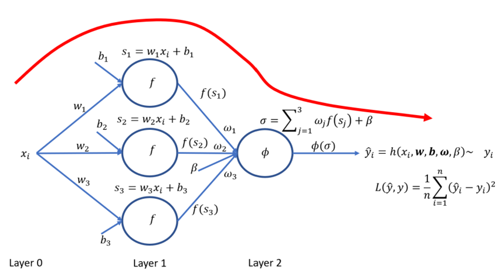

ANNs typically consist of a node layer (layer 0 as seen in the diagram), containing the input, and occasionally at least one hidden layer which does further processing of data (layer 1 and layer 2), and an output layer. The hidden layers can take on the activation functions mentioned earlier, although the more common ones covered were ReLu and Softmax function, each more suited towards certain prediction tasks. The inputs from the input layer are passed into the first hidden layer with certain weights($w_i$) and biases ($b_i$), to modify the significance of the inputs. The activation function in the first layer need not necessarily be the same as those in the subsequent hidden layers. Subsequently, the outputs from the first hidden layer are passed into the next hidden layer, and modified by another weight constant and bias. This process is repeated till the last layer which will then give an output label that is a predicted result based on the input, which may differ from the actual label. The forward flow of calculations to determine the loss function is as follows:

$$\begin{aligned}
\begin{aligned}
L(\hat{y},y)&=\frac{1}{n}\sum_{i=1}^n(\hat{y}_i-y_i)^2=\frac{1}{n}\sum_{i=1}^n(\phi(\sigma_i)
-y_i)^2\\
&=\frac{1}{n}\sum_{i=1}^n(\phi(\sum_{j=1}^3\omega_jf(s_{ji})+\beta)
-y_i)^2=\frac{1}{n}\sum_{i=1}^n(\phi(\sum_{j=1}^3\omega_jf(w_jx_i+b_j)+\beta)
-y_i)^2
\end{aligned}
\end{aligned}$$

## Classification Neural Network

The Classification Neural Network is an example of an ANN that is specifically for classification of the input data. The general concept for this neural network is that it estimates the probability that an input data can be classed into one of the predefined categories. The predefined category with the highest probability will then be selected as the classification prediction for that specific input data. The structure of a classification neural network is similar to what is described for a generic ANN where the data will be input into a layer of nodes, then passed into a hidden layer for processing, with the respective weights and biases applied, and this is repeated for however many hidden layers there are till the output layer. However, some things to note for this neural network is that the number of outputs for the neural network has to coincide with the number of categories being predicted. Furthermore, since the outputs are probabilities and we want to choose the prediction to be a specific category, we will thus have to utilise the Softmax activation function in at least the final hidden layer to determine the output. The Softmax function leverages on the gibbs measure:
$$p_c=\frac{e^{s_c/\lambda}}{\sum_{k=1}^C {e^{s_k/\lambda}}}$$
The gibbs measure allows for convergence towards the class of the highest probability, to ustilise the one-hot encoding, to identify the predicted class.

## Convolutional Neural Network (CNN)

Once again, the CNN is another form of an ANN. The characteristics of CNN is that it takes time serieses into account during its prediction. Some operations used for a CNN is filtering, padding, striding, pooling, and flattening. The hidden layers within the CNN are also known as the convolution layers as they apply the aforementioned operations to modify the original input for processing.

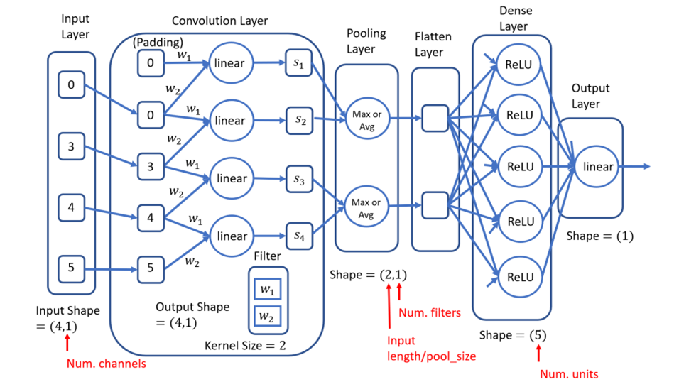

Typical 1D Convolutional Neural Network

In this diagram, the hidden layer is made up of the convolution layer, pooling layer, flatten layer, and dense layer. Padding is used to maintain the size of the input data after being filtered and passed through the first activation function. The output from the convolution layer can then be pooled in the pooling layer to obtain the average or the maximum value within a certain interval of data, as specified by the size of the stride. Flattening is used to convert the data that has been output from the previous layers into a one-dimensional matrix to be passed into and processed by the next dense layer with a specific activation function. The output of this dense layer is then passed into the output layer to obtain a final output based on the specified activation function.

# Recurrent Neural Network (RNN) Introduction

Having detailed the three neural networks that we currently understand, we will now introduce the theory behind an RNN, and observe how it differs from the three neural networks earlier.

## Recurrent Neural Network (RNN) Theory

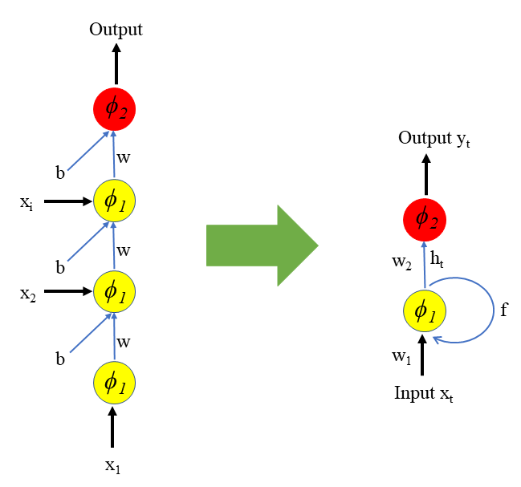

Simplified Recurrent Neural Network Diagram

An RNN can be described as a feedforward neural network that has a series of hidden layers with their respective activation functions being fed an input from the main dataset. However, in a standard feedforward neural network, each hidden layer is characterised by their respective activation function and weights and biases, receiving the output from the previous layer as its input. This causes the hidden layers to act independently, and causes the inputs from the main dataset to be independent of one another too. Instead, in an RNN, as can be seen in the diagram above, the hidden layers are fed with input from the main dataset directly and the output from the previous layer, and each hidden layer has the similar weights and biases. This introduces dependency between the layers and inputs, and can be condensed into a single recurrent neuron/node that receives its input from the main dataset, and the output from the neuron/node itself is fed back into itself through a recurrence formula. This will allow the recurrent neuron/node to store the state of the previous input and combine it with the current input, thus introducing dependency between the previous and current input. The recurrence formula can be written as $h_t=f(h_{t-1},x_t)$, where the function $f$ can take on any activation function. For example, if the activation function is $tanh$, then $h_t=tanh(W_3H_{t-1} + W_1x_t)$. Here, $h_t$ represents the new state, $h_{t-1}$ represents the previous state, and $x_t$ is the current input. Each successive input is known as a time step represented by $t$. Weight $W_1$ and bias $b$ is the weight at the input neuron/node, $W_3$ is the weight within the recurrent neuron/node, that is being applied to the previous hidden state $h_{t-1}$, and $W_2$ is the weight at the output node to give $\hat{y}_t$. The obtained current state is simultaneously fed as an input into the output neuron/node with its own activation function, with the weight $W_2$ applied. This produces a prediction $\hat{y}_t$, calculated by $\hat{y}_t= W_2h_t$, which will be used to calculate an error which is back propagated to the network to update the weights. The flow of information described can be classified as a “many to one” type of RNN architecture, that is to say that the input is a sequence, and the hidden states are a function of both the input at a specific time step and previous hidden states. A “many to one” architecture will only produce one output. There are other types of RNN architecture such as the “one to many” architecture as shown in the diagram below:

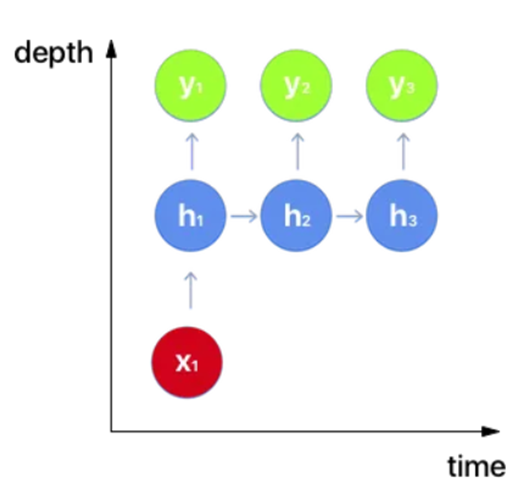

One to many architecture for RNN

Briefly, the “one to many” architecture requires only one input at each time step, an only the first hidden state ($h_1$) is dependant on the input ($x_1$), while the remaining hidden states are dependent on only the previous hidden state (ie. $h_3$ dependent on $h_2$, $h_2$ dependent on $h_1$). All hidden states will produce and output respectively ($y_1$,$y_2$ and $y_3$).

Another architecture is the “many to many” architecture as seen below:

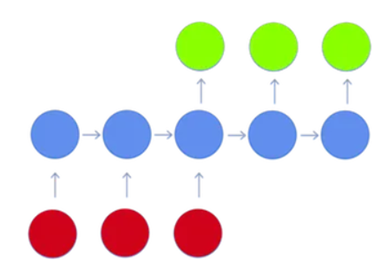

Many to Many architecture for RNN

In this architecture, both the inputs and outputs are sequential, where all the outputs including the first, is a function of all the inputs.

**Back propagation through time** The idea of back propagation is to back track the time steps to change the weights acting on the inputs. When the network is unrolled, it can be seen as a series of feedforward neural networks where each layer is connected by a set of weights and biases.

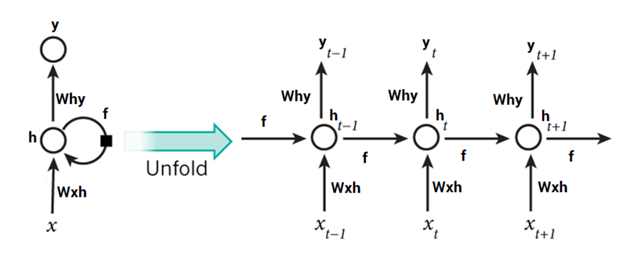

Unrolled/Unfolded RNN diagram

In the diagram above, the recurrent neruon/node has been unrolled/unfolded to reveal a feedforward neural network, where each node is at a specific time step $t$, with an input $x_t$, weight $W_{xh}$ applied to $x_t$, and recurrence formula $f$ forming a relationship between the current input and the previous hidden state $h_{t-1}$ to give a new hidden state $h_t$ weighted by $W_{hy}$, to produce output $y_t$ at the current time step $t$. In the case of an RNN, if $\hat{y}_t$ is the predicted value, and $y_t$ is the actual value, the error is calculated as a cross entropy loss below:

$$\begin{aligned}
{\sum}_t(y_t, \hat{y}_t) &= -y_t log(\hat{y}_t) \\
{\sum}(y, \hat{y}) &= - {\sum} y_t log(\hat{y}_t) \\
\end{aligned}$$

$$ Total error (${\sum}(y, \hat{y})$) is the sum of errors at each time step. At each time step, the weights and biases applied are identical. In order to adjust the weights, we will have to calculate the first order derivative (ie gradient) at each node, taking into consideration its relationship with the previous node and hidden state.

Take for example, we would like to adjust the weight $W_S$ applied to a hidden state at time step $t+1=3$, where $W_S$ is the weight associated with the hidden state in the function $f$. For ease of calculation, we shall use a simpler squared error function $E_t = (y_t - \hat{y}_t)$. Differentiating the error function wrt to $W_S$ to get equation $\frac{\partial E_3}{\partial W_S}$. To elaborate, $E_3$ is a function of $y_3$, $y_3$ is a function of $f_3$, and $f_3$ is a function of $f_2$ and $W_S$. However, $f_2$ is also a function of $f_1$ and $W_S$. Since the error function $E_3$ is a function of $f_2$ and $f_1$, we will thus have to take into account the derivatives of $f_s$ wrt to $W_S$ and $f_1$ wrt to $W_S$. As such, by the chain rule, we obtain the following equation: $$

$$\begin{aligned}
\frac{\partial E_3 }{\partial W_S} = &(\frac{\partial E_3 }{\partial
y_3} \cdot \frac{\partial y_3 }{\partial h_3} \cdot \frac{\partial h_3
}{\partial W_S}) + \\
& (\frac{\partial E_3 }{\partial y_3} \cdot \frac{\partial y_3
}{\partial h_3} \cdot \frac{\partial h_3 }{\partial h_2} \cdot
\frac{\partial h_2 }{\partial W_S}) + \\
& (\frac{\partial E_3 }{\partial y_3} \cdot \frac{\partial y_3
}{\partial h_3} \cdot \frac{\partial h_3 }{\partial h_2} \cdot
\frac{\partial h_2 }{\partial h_1} \cdot \frac{\partial h_1 }{\partial
W_S})
\end{aligned}$$

$$ The equation can be summarised as such, where $N$ represents the time step $t$ in question.

$$\begin{aligned}
\frac{\partial E_N }{\partial W_S} = & \sum_{i=1} ^N
(\frac{\partial E_N }{\partial y_N} \cdot \frac{\partial y_N }{\partial
h_i} \cdot \frac{\partial h_i }{\partial W_S}) \\
\end{aligned}$$

Similarly, adjusting the weight $W_{xh}$ that is associated with the input $x_t$ at each time step can be summarised as: $$

$$\begin{aligned}
\frac{\partial E_N }{\partial W_{xh}} = & \sum_{i=1} ^N
(\frac{\partial E_N }{\partial y_N} \cdot \frac{\partial y_N }{\partial
h_i} \cdot \frac{\partial h_i }{\partial W_{xh}}) \\
\end{aligned}$$

And adjusting $W_{hy}$, the weight associated with giving the output $y_t$ from the hidden state $h_t$ can be summarised as: $$

$$\begin{aligned}
\frac{\partial E_t }{\partial W_{hy}} =
(\frac{\partial E_t }{\partial y_t} \cdot \frac{\partial y_t }{\partial
W_{hy}}) \\
\end{aligned}$$

When the dependencies are short-term, meaning that the total time step does not take on a large value, RNN performs well in predicting the output. Unfortunately, RNNs do not “understand” the context of an input well. This means that in the case of a large input with many time steps, the neural network is unable to recall the earlier time steps well as compared to the most recent input. Thus, the predictions fail to produce an output of relevance to the context. This is known as the Vanishing Gradient problem. The Vanishing Gradient problem happens when the algorithm in a multilayer neural network, such as RNN, back propagates the gradient from the output end of a layer towards the initial layer, causing the gradient to approach zero. This results in the weights towards the initial layers remaining unchanged, impeding the learning effectiveness.

The Vanishing Gradient problem can be mitigated with the implementation of a modified RNN known as the Long Short-Term Memory Network.

## Long Short-Term Memory (LSTM) Network

However useful RNN may seem, it is not without pitfalls, such as the inability to recall the inputs from an earlier time step. This is where Long Short-Term Memory (LSTM) Networks are introduced to mitigate this disadvantage. In a nutshell, LSTMs make minor adjustments to information by multiplication and additions. The overall structure of an LSTM can be seen in the diagram below:

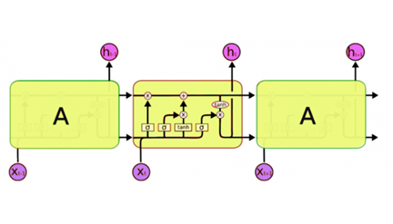

Overall LSTM Diagram

The inputs are fed into a memory block (AKA Cells A), to produce a cell state and hidden state. The cell states are a function of the following 3 items: *The previous cell state which is the information present in the memory after the previous time step* The previous hidden state which is output of the previous cell, similar to a node in a normal RNN *The input at the current time step which is new information being introduced to the neural network in that instant. A cell is capable of storing data into its memory via 3 main ways known as Gates. The first gate is the Forget Gate, which helps a cell remove information from the cell state. The information removed is either not required for the LSTM in understanding the overall context of the input, or it is considered of less importance.

The Forget Gate has inputs $h_{t-1}$, the hidden state from the previous cell, and $x_t$, the input at a specific time step. As usual, the weights and biases are applied to the inputs. The inputs are then passed into a sigmoid function ($\sigma$), which outputs a vector ft with a range from 0 to 1, where 0 means that the gate wants to completely forget the particular value in that cell state, and 1 means remember the information entirely. The output $f_t$ is then multiplied to the cell state.

The second gate is the Input Gate, which serves to add relevant and important information to the cell state via a 3 step process with the following structure:

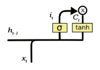

LSTM Input Gate Diagram

The 3 step process is as follows: 1. Using a sigmoid function ($\sigma$), similar to the Forget Gate, filter the information to be added to the cell state from the inputs $h_{t-1}$ and $x_t$. The output is $i_t$. Using the $tanh$ function, a vector ($C_t$) containing all possible values to be added from the inputs is created. The values in $C_t$ range from -1 to 1 Take $i_t * C_t$, which represents useful information, and add it to the cell state.

The third and final gate is the Output Gate, which serves to select useful and relevant information from the current cell state as the output.

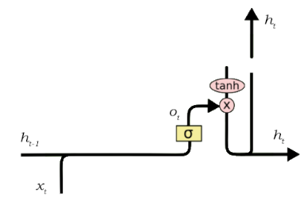

LSTM Output Gate Diagram

The structure is as shown above, with the following functionalities: 1. From the cell state, apply the $tanh$ function, to create a vector whose values are scaled from -1 to 1 2. Using a sigmoid function ($\sigma$) on the the inputs $h_{t-1}$ and $x_t$, an output $O_t$ is created, which serves as a filter to decide which scaled values from the $tanh$ function in step 1 will be an output to create the current hidden state $h_t$ 3. Combine $O_t$ and the vector created from the $tanh$ function via multiplication, forming the current hidden state $h_t$, to be used in the next cell.

In summary, an LSTM adds a memory block known as a cell at every time step, which consists of 3 gates – the Forget Gate, Input Gate, and Output Gate – serving to remove useless and irrelevant information from a cell state, selecting relevant information from the inputs and adding to the cell state, and filtering and selecting the most relevant information as an output to be the current hidden state.

# Application to Image Captioning

In image captioning using machine learning, we have to understand that there will be 2 sets of inputs to train the model. The first will be an image, and the second will be words associated with the image.

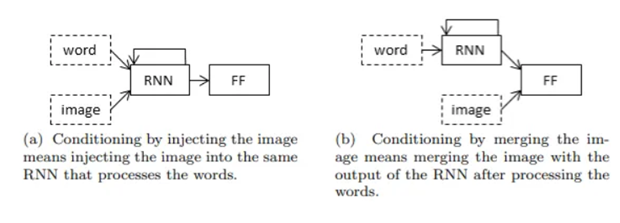

Two Main Image Captioning Architecture

As seen from this diagram, there are 2 main architectures used in machine learning for image captioning. The first is the Injecting architecture where both the image data and language data is input into the neural network simultaneously, training the model on a mixture of both the inputs. In the case of the RNN model, it will use both the language data and image data to predict the next word for the image captioning, while also fine tuning the image data during the training. There are 3 sub-variants of the Injecting Architecture, mainly: 1. Init - inject – where the hidden state vector of the RNN utilises the image data vector. 2. Pre-inject – where the image data vector is used as the first word in the prefix 3. Par-inject – where the 2 inputs (word and image data) are fed into the RNN simultaneously at each time step. In the Merging architecture, the image data is not fed into the RNN at all, and instead fed into the feed-forward network instead, separating the encoding of both the information. A summary of the 3 sub-variants of the Injecting architecture and the Merging architecture can be seen in the diagram below.

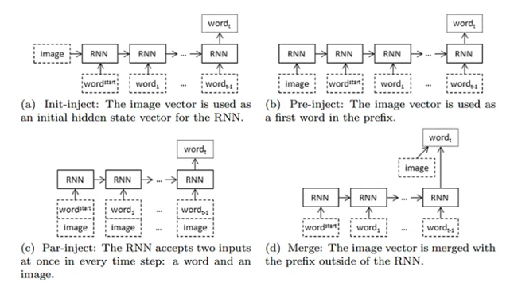

Four Total Image Captioning Architecture

However, in image captioning, we have to realise that the image data cannot be the image itself. In order to decompose a complex image into its data, we thus have to execute image feature extraction, which can be done using a CNN.

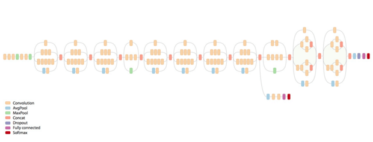

Image Captioning CNN Architecture

In a nutshell, a CNN architecture of image classification can be seen from the diagram above. However, since we are not classifying the images, the activation layers (red softmax layer) will be dropped from the architecture. Instead, the convoluted features will be used directly as the extracted image features and fed into the RNN network as seen in the diagram below.

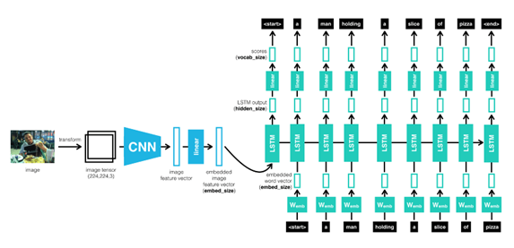

Main Image Captioning Architecture

An additional step required is to convert the image caption in the dataset into tokens, in a process known as word-embedding, where the words are represented as a vector.

## How is RNN Used in Image Captioning?

The architecture employed in our image captioning model is the Merging Architecture, where the captions fed into an RNN model independent of the image features. The image features and word output are then fed into feed forward neural network at the end to produce a predicted caption. The RNN/LSTM model described in the theory can be summarised into a single neural network layer in the learning model. That layer is “layer_lstm()”, native to the keras package. The overall architecture is as such:

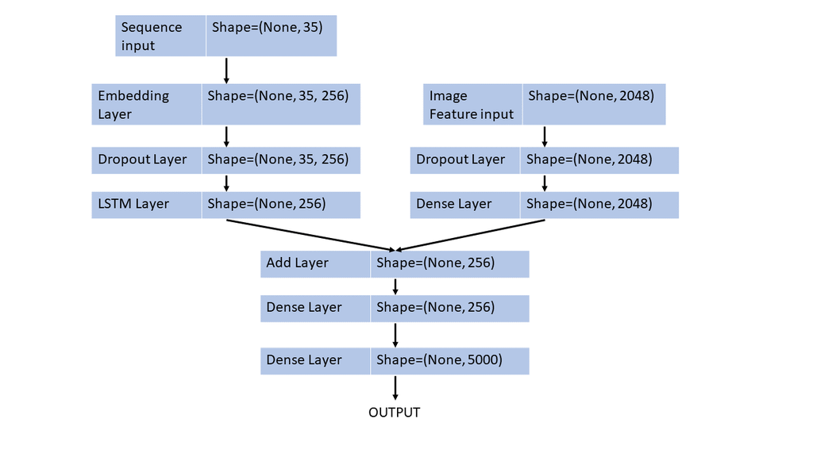

Image Captioning Merging Architecture Employed

**Sample Code** Due to the code being a large file, please refer to “image captioning.RMD”

The steps taken in the code to construct the model is as such: 1. Process the captions into sequences of indexes via tokenization 2. Process the images to extract its features of dimension 1x2048 3. Generate a large list of input data that associated the image features with its respective captions as input sequences and true outputs. The true outputs are the target words that comes after the input sequence 4. Construct the image captioning model which has 1 for the captions which goes into the LSTM model, and 1 input for the features that goes into the feed forward network. 5. Predict caption for any selected validation image

A summary of certain outputs can be seen below.

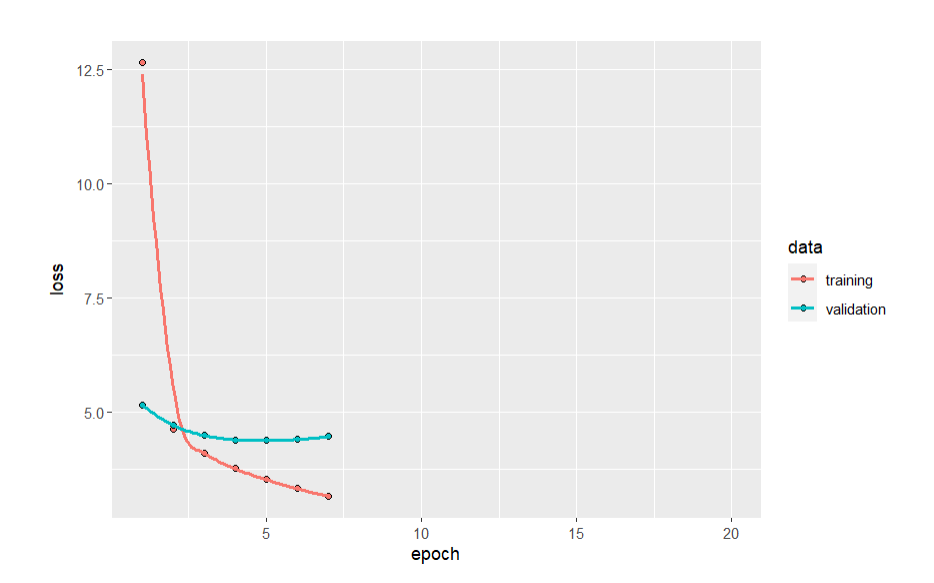

Loss vs Epoch

Presented here is the loss per epoch of the model. As can be seen there is some form of overfitting, thus the early truncation of the epoch before the target epoch. The current parameters of dropout rate = 0.5, and having no regularisation of the layers seem to perform better as compared to having a lower dropout rate of 0.3 and l1 regularisation 0.01.

As for the following image;

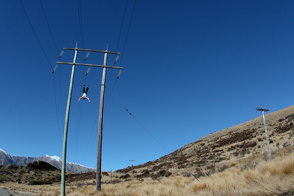

These are the respective actual and predicted captions.

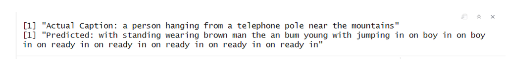

Actual vs Predicted Captions

For evaluating the model, other than using the in-built keras “evaluate()” function, there is a more specific evaluation metric for Image captioning known as BLEU. Briefly, the BLEU measures the predicted output from 0, indicating a total mismatch, to 1, a complete match. A complete match often means an identical match to a reference, and is unrealistic and unnecessary to obtain 1. A generally higher score close to 1 is desirable.

**Limitations** + Hardware limitation limit how much the model can be trained + The dataset used might be insufficient in training the model

**Improvements** + Increasing the dataset size is a possibility, however, a much longer training time will be required + The model can be refined via including more layers and making it more complicated + Exploring more efficient data structures to store large amounts of intermediate data for the input data would greatly benefit the training efficiency and time.

# Conclusion

To summarise, RNNs have a plethora of applications, image captioning being one of them. The recurrent unit in an RNN predicts an output at a specific timestep, that is a function of the current input and previous inputs, with specific weights applied. These weight values are updated with each time step via backpropagation. To improve the efficiency of the RNN, LSTMs are used, to enhance the contextual memory of an RNN. By using this model, we are able to process words and natural language, enabling us to create the image captioning model.